# Loftgæði

Samantekt á mælingum köfnunarefnisdíoxíðs (NO2) við Grensásveg

Nýlega var fjallað um óvenjulega háar mælingar á NO2 í Reykjavíkurborg. Hversu algeng eru slík tilvik? Hér ber ég mælingar ársins 2023 saman við fyrri ár.

loftgæði

umhverfi

Höfundur

Stofnun

[Brynjólfur Gauti Guðrúnar Jónsson](https://twitter.com/bgautijonsson)

[Tölfræði, Raunvísindadeild Háskóla Íslands](https://www.hi.is/tolfraedi_0)

Síðast uppfært

January 21, 2023

Á [vef Umhverfisstofnunar](https://ust.is/loft/loftgaedi/kofnunarefnisdioxid/) er skrifað:

> Í stórum þéttbýliskjörnum getur styrkur köfnunarefnisoxíða nálgast mörkin þar sem áhrifa á heilsu manna fer að gæta. Köfnunarefnisdíoxíð (NO2) ertir lungu manna og dýra og meðal annars er talið að langvarandi álag á lungu af völdum NO2 geti valdið lungnaskemmdum síðar á ævinni. Enn fremur getur hár styrkur köfnunarefnisoxíða orsakað plöntuskemmdir.

> Vegna legu Reykjavíkur við hafið og hve vindasamt er þar, er meðalstyrkur köfnunarefnisdíoxíðs sjaldan meiri en 20 µg/m3 á veturna. En þegar logn er á veturna getur myndast mjög greinilegt slör af menguðu lofti yfir borginni og þá fer magn köfnunarefnisdíoxíðs á sólarhring stundum yfir viðmiðunarmörkin sem eru 75 µg/m3.

Á myndinni að neðan sjáum við hversu oft og hvenær mælingar köfnunarefnisdíoxíðs (NO2) hafa farið yfir hættumörkin, bæði hvað varðar klukkustundarmörk og dagsmörk, síðan 2019.

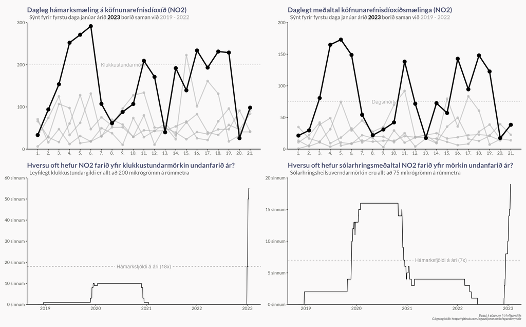